# Advanced Bioinformatics 2022 Assessment

### Task 3.7

#### Again using the cars dataset, now use linear regression (lm) to estimate the average reaction time for the driver to start breaking (in seconds). To simplify matters you may assume that once breaking commences, breaking distance is proportional to the square of the speed. Explain the steps in your analysis. Do you get reasonable results? Finally, use ggplot to plot the data points and the fitted relationship. (10pt)

```r
data(cars)

cars$speedms <- (cars$speed*0.44704)   #mph -> metres/sec
cars$BDm <- (cars$dist)*0.305 #ft -> metres

#The braking distance can be split into two components:
#Distance = Reaction Time Distance + Braking distance

#As per the question, we can assume:
#Braking Distance ~ Speed^2

#Therefore we need to determine the reaction time distance relationship which should be directly proportional to the initial speed of the vehicle:
#Reaction Time Distance ~ Speed

#Putting this together we get the suggested model of:
#BDm ~ a*speedms + b*speedms^2 + c   and given distance = speed*time whereby a is the estimated reaction time.

# We can assume that when speed is equal to 0, distance is also equal 0 and can
#therefore remove the implied intercept from the model so that the curve
#intersects the axis at the origin by applying the -1 syntax at the end of our
#formula as specified in the R documentation (y ~ x - 1)

mlr <- lm(BDm ~ speedms + I(speedms^2)-1,cars)
summary(mlr)
```

```
##
## Call:
## lm(formula = BDm ~ speedms + I(speedms^2) - 1, data = cars)
##
## Residuals:
##     Min      1Q  Median      3Q     Max
## -8.7950 -2.7666 -0.9614  1.3938 13.7208
##
## Coefficients:
##              Estimate Std. Error t value Pr(>|t|)
## speedms       0.84535    0.38205   2.213  0.03171 *
## I(speedms^2)  0.13757    0.04485   3.067  0.00355 **
## ---
## Signif. codes:  0 '***' 0.001 '**' 0.01 '*' 0.05 '.' 0.1 ' ' 1
##
## Residual standard error: 4.582 on 48 degrees of freedom
## Multiple R-squared:  0.9133, Adjusted R-squared:  0.9097
## F-statistic: 252.8 on 2 and 48 DF,  p-value: < 2.2e-16
```

```r
#Adjusted R-squared:  0.9097
```

#Therefore, the estimated driver reaction time equals the constant as 0.85 #seconds. The p-values of each relationship are <0.05 and therefore significant #based on 95% confidence. This result is reasonable as on average, reaction times #are typically between 0.2 seconds and 0.9 s. (https://www.bbc.co.uk/bitesize/guides/zq4mfcw/revision/3)

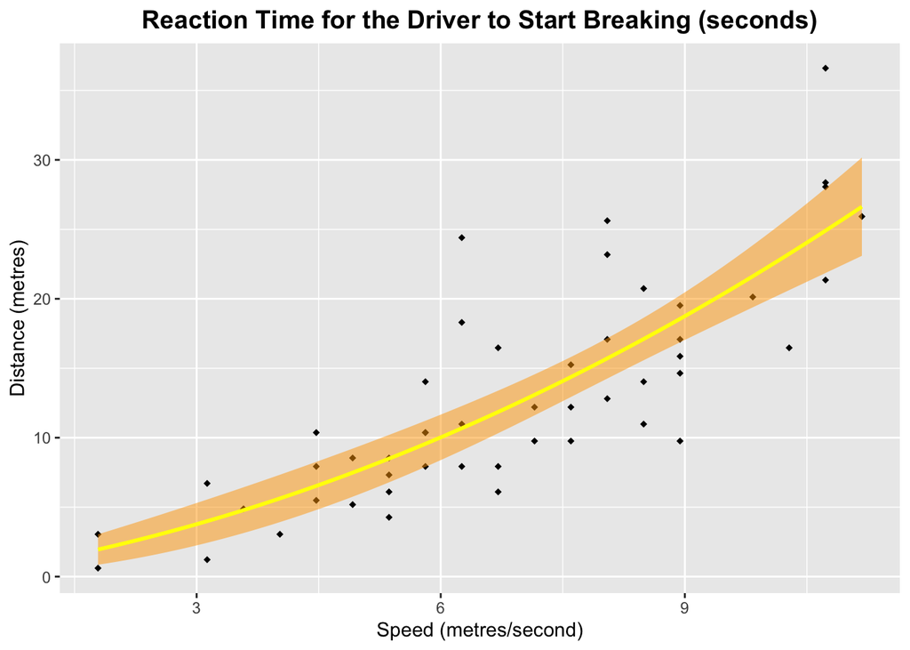

```r
ggplot(cars, aes(x = speedms, y = BDm)) +
  geom_point(shape=18) +
  geom_smooth(method = "lm", formula = "y ~ x + I(x^2)-1", alpha=0.5, colour="yellow", fill="orange") +
  ggtitle("Reaction Time for the Driver to Start Breaking (seconds)") +
  ylab("Distance (metres)") +
  xlab("Speed (metres/second)") +
  theme(plot.title = element_text(size = 14, face = "bold", hjust = 0.5))
```